## Q1: İş, Problem ve İhtiyaç Tanımı

### Q1.1 İş Tanımı

Firma Adı: Bety Social Media Consultancy

Bety Social Media Consultancy, dijital pazarlama stratejileri üzerine uzmanlaşmış bir danışmanlık firmasıdır. YouTube platformunda içerik üretimi yapmak isteyen markaların ve bireylerin dijital varlıklarını yönetmek ve büyütmek için veri odaklı çözümler sunar. Müşterilerine hedef kitlelerine ulaşmaları ve abone sayılarını artırmaları konusunda destek sağlar.

### Q1.2 Problem ve İhtiyaç

Şirketimizin karşılaştığı temel problem, YouTube platformunda içerik üretimi yapmak isteyen müşterilerin hangi konseptin daha çok ilgi çekeceğini ve gelir getireceğini belirleyememeleridir. Bu nedenle, müşterilerimizden gelen talepler doğrultusunda doğru içerik stratejilerini belirleyebilmek için kapsamlı bir veri analizine ihtiyaç duyulmaktadır.

### Q1.3 Çözüm

#### Çözüm Önerisi - Veri Seti Tanımı

Bulduğumuz veri seti, YouTube platformunda yer alan kanalların Global Youtube 2023 istatistiklerini içermektedir. Bu veri setinde, kanalların abone sayıları, izlenme sayıları, videoların kategorileri ve içerik türleri gibi parametreler bulunmaktadır.

#### Çözüm Önerisi - Planlanan Analiz (Özet)

Yapmayı planladığımız analizde, veri setini kullanarak belirli bir bölge veya ülkede en çok bulunan kanal kategorisini, konsept istatistiklerini belirlemeyi amaçlıyoruz. Bunun için, veri setini filtreleyip, kanalları seçecek ve bu kanalların kategorilerini ve içerik türlerini analiz edeceğiz. Bu analiz, müşterilerimize hangi içerik konseptlerinin daha fazla ilgi çekebileceği konusunda bilgi sağlayacaktır.

#### Çözüm Önerisi - Planlanan Analiz Sonuçları

Analizimiz sonucunda elde edeceğimiz KPI’lar şunlar olacak: - Belirli bir bölgede veya ülkede en gelir elde eden kanalların kategorileri ve içerik türleri - En popüler içerik konseptlerinin görselleştirilmiş istatistikleri - Müşterilerimize önerilecek içerik stratejileri ve konseptleri

## Q2: Veri İthali

```r
library("RSQLite")
library("DBI")
library(readr)
library(dplyr)
```

```r
library(ggplot2)
library(haven)

dbname<-"Vize_Q2_190401029_Cengiz_Betul.sqlite"

con<-Package::connect_to_database(dbname)

youtube <- read.csv("GlobalYouTubeStatistics.csv")

dbWriteTable(con, "youtube", youtube, overwrite = TRUE)
```

## Q3: Veri Kalite Kontrolü

```r
# Verileri veritabanından çek
youtube_data <- Package::get_youtube_data()
Package::dataTypes(youtube_data)
```

```
##                                    rank                                Youtuber
##                               "integer"                             "character"
##                             subscribers                             video.views
##                               "integer"                                "double"
##                                category                                   Title
##                             "character"                             "character"
##                                 uploads                                 Country
##                               "integer"                             "character"
##                            Abbreviation                            channel_type
##                             "character"                             "character"
##                        video_views_rank                            country_rank
##                               "integer"                                "double"
##                       channel_type_rank        video_views_for_the_last_30_days
##                                "double"                                "double"
##                 lowest_monthly_earnings                highest_monthly_earnings
##                                "double"                                "double"
##                  lowest_yearly_earnings                 highest_yearly_earnings
##                                "double"                                "double"
##            subscribers_for_last_30_days                            created_year
##                                "double"                                "double"
##                           created_month                            created_date
##                             "character"                                "double"
## Gross.tertiary.education.enrollment....                              Population
##                                "double"                                "double"
##                       Unemployment.rate                        Urban_population
##                                "double"                                "double"
##                                Latitude                               Longitude
##                             "character"                             "character"
```

```r
# Filtrelenmiş veriyi yeni bir veri çerçevesine kaydet
```

```r
new_data <- Package::filteredData(youtube_data)
# Yeni veriyi inceleyin
new_data
```

```
##     rank                                         Youtuber subscribers
## 1      2                                   YouTube Movies   170000000
## 2      3                                          MrBeast   166000000
## 3      4                       Cocomelon - Nursery Rhymes   162000000
## 4      7                              ııı Kids Diana Show   112000000
## 5     10                                    Vlad and Niki    98900000
## 6     12                                              WWE    96000000
## 7     19                                           Sports    75000000
## 8     23      Pinkfong Baby Shark - Kids' Songs & Stories    68200000
## 9     29                                     Dude Perfect    59500000
## 10    30                                       Movieclips    59500000
## 11    36                                      EminemMusic    56900000
## 12    37                                       Marshmello    56400000
## 13    42                                     Taylor Swift    52900000
## 14    43                                    Ariana Grande    52700000
```

[output cut: 2712 more lines]

```r
modified_data <- Package::replace_na_with_zero(new_data)
modified_data
```

```
##     rank                                         Youtuber subscribers
## 1      2                                   YouTube Movies   170000000
## 2      3                                          MrBeast   166000000
## 3      4                       Cocomelon - Nursery Rhymes   162000000
## 4      7                              ııı Kids Diana Show   112000000
## 5     10                                    Vlad and Niki    98900000
## 6     12                                              WWE    96000000
## 7     19                                           Sports    75000000
## 8     23      Pinkfong Baby Shark - Kids' Songs & Stories    68200000
## 9     29                                     Dude Perfect    59500000
## 10    30                                       Movieclips    59500000
## 11    36                                      EminemMusic    56900000
## 12    37                                       Marshmello    56400000
## 13    42                                     Taylor Swift    52900000
## 14    43                                    Ariana Grande    52700000
```

[output cut: 2712 more lines]

## Q4: Veri Analizi

#### Veri analizimize , daha önce veri kontrolünü yapmış olduğumuz verilerimiz ile işlemlerimize devam ediyoruz.

```r
# modified_data veri çerçevesini CSV dosyasına kaydedin
write.csv(modified_data, file = "modified_data.csv")
# lowest_yearly_earnings sütunundaki ortalamayı hesaplayın
ortalama_yuksek_kazanc <- mean(modified_data$highest_yearly_earnings)
# Ortalama değeri yazdırın
print(ortalama_yuksek_kazanc)
```

```
## [1] 6904969
```

#### Tüm kazançlardan ortalama en yüksek kazancı buluyoruz

#### Daha sonra bu ortalama değerin üzerinde olan kazanç değerlerini buluyoruz

```r
# 2. Ortalamanın Üzerindeki Değerleri Bulma

# Ortalama değerin üzerinde olan highest_yearly_earnings değerlerini seçin
yuksek_kazanc_veri <- modified_data[modified_data$highest_yearly_earnings > ortalama_yuksek_kazanc, ]
print(yuksek_kazanc_veri)
```

```
##     rank                                         Youtuber subscribers
## 2      3                                          MrBeast   166000000
## 3      4                       Cocomelon - Nursery Rhymes   162000000
## 4      7                              ııı Kids Diana Show   112000000
## 5     10                                    Vlad and Niki    98900000
## 6     12                                              WWE    96000000
## 8     23      Pinkfong Baby Shark - Kids' Songs & Stories    68200000
## 11    36                                      EminemMusic    56900000
## 13    42                                     Taylor Swift    52900000
## 14    43                                    Ariana Grande    52700000
## 15    44 BillionSurpriseToys  - Nursery Rhymes & Cartoons    52200000
## 16    46                                    Billie Eilish    47900000
## 17    50                               SonyMusicIndiaVEVO    46600000
## 19    68                               Masha and The Bear    42400000
## 26    91                                     Daddy Yankee    38000000
```

[output cut: 714 more lines]

- Ortalamanın üzerinde bulduğumuz kazanç değerlerine sahip kanalların kanal tipini analiz ederek görselleştiriyoruz.
- Elde ettiğimiz verilere göre United States’de ortalamanın üzerinde kazanmak isteyen bir müşterinin YouTube platformuna kanal tipi olarak “Eğlence” içeriği ile girişi yapmasının mantıklı olacağını gözlemliyoruz.

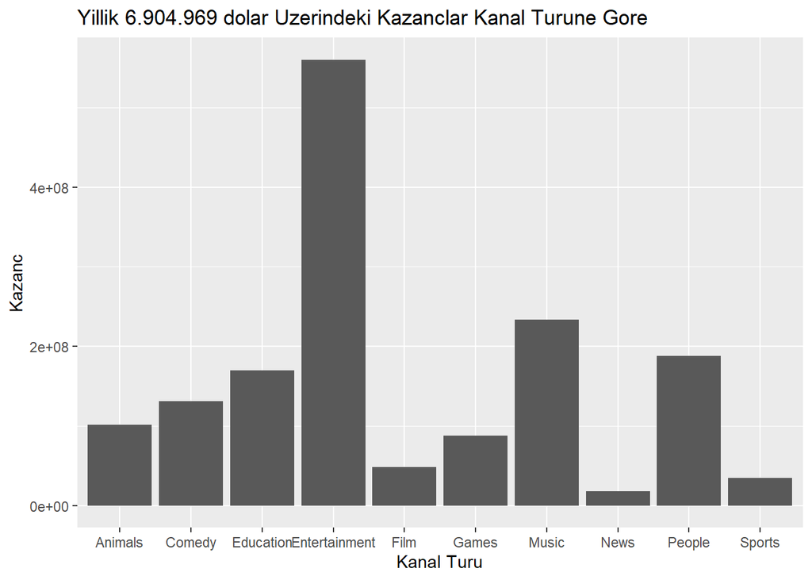

```r
# 3. Kanal Tiplerini Bulma

# Seçilen satırların indekslerini bulun
yuksek_kazanc_indeksler <- which(modified_data$highest_yearly_earnings > ortalama_yuksek_kazanc)

# Bu indekslere göre kanal tiplerini seçin
yuksek_kazanc_kanal_tipleri <- modified_data$channel_type[yuksek_kazanc_indeksler]

# 4. Grafik Oluşturma

# ggplot2 paketini yükleyin (eğer yüklü değilse)
library(ggplot2)

# Çubuk grafiği oluşturun
ggplot(yuksek_kazanc_veri, aes(x = channel_type, y = highest_yearly_earnings)) +
  geom_bar(stat = "identity") +
  labs(title = "Yillik 6.904.969 dolar Uzerindeki Kazanclar Kanal Turune Gore", x = "Kanal Turu", y = "Kazanc")
```

- Bir diğer analizimizde ise bu sefer kazanç değerleri aksine abone sayılarını baz alıyoruz ve en çok abonoye sahip olan ilk 100 kanalın kanal tipini bir grafik ile görselleştiriyoruz.
- Kazanç değerlerinden farklı olarak United States de eğer fazla aboneye sahip olmak istiyorsanız Müzik kanal tipi ilk sırada gelirken Eğlence kanal tipi 2. sırada yer alıyor.

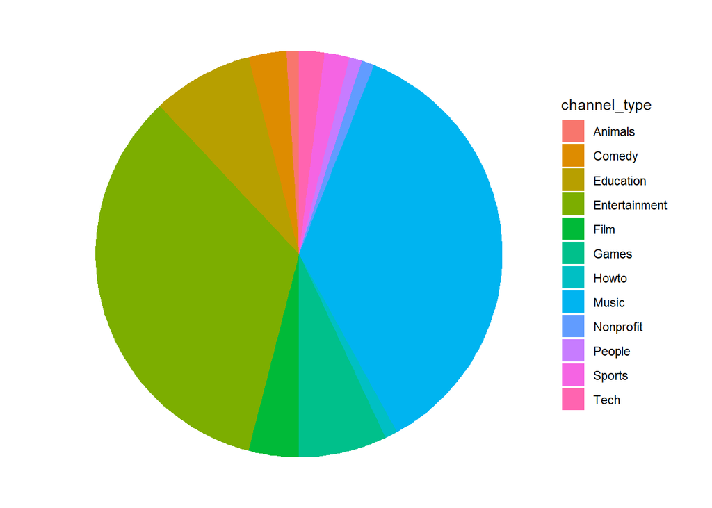

```r
dataP <- head(modified_data, 100)

# Pasta grafik oluştur
p <- ggplot(dataP, aes(x = "", fill = channel_type)) +
  geom_bar(width = 1) +
  coord_polar("y", start = 0) +
  theme_void()

# Grafik nesnesini görüntüle
print(p)
```

## Q5: Sonuçlar ve Değerlendirmeler

- Analizlerimize göre, veri setini kullanarak belirli kanal türlerinin performansını ve trendlerini başarıyla belirledim. Özellikle, United States’de Eğlence içerikli kanalların ortalamanın üzerinde kazanç elde etmek için mantıklı bir seçenek olduğunu ve Müzik kanallarının abone sayılarına göre öne çıktığını gözlemledim. Bu sonuçlar, veri analizimizin istenilen sonuçlara ulaşma başarısını göstermektedir.
- Şirketimizden danışmanlık isteyen müşterimizin problemi United States’de yeni bir Youtube kanalı girişimcisi olarak hangi kanal tipinde içerik üretirse başarılı olabileceği idi.Analiz sonuçlarımıza göre öncelikle yıllık olarak ortalamanın üstünde bir gelir elde etmek istiyorsa “Entartainment” tipinde bir kanal ile girişimini başlatması önerisinde bulunduk.Diğer yandan gelir miktarını filtrelemeden abone kazanıp daha çok popüler olması konusunda bir öneri olarak ise “Music” içerik üreticisi olmasını önermekteyiz.

#### Çalışmanın Genişletilmesi ve Devamı İçin Öneriler:

- Gelecekteki çalışmalarım için, belirli kanal türlerinin performansını daha ayrıntılı olarak incelemeyi düşünüyorum. Örneğin, kazançları etkileyen faktörleri veya abone sayılarını artıran stratejileri daha derinlemesine araştırarak daha kapsamlı bir analiz sunabilirim.
- Ayrıca, coğrafi bölgelere göre eğilimleri karşılaştırarak küresel bir perspektif sunmak da ilginç olabilir. Veri setini genişletmek ve farklı kaynaklardan elde edilen verilerle birleştirmek de analizlerimi geliştirmek için faydalı olabilir.
- Son olarak, analizlerimin sonuçlarını daha açıklayıcı ve detaylı bir şekilde sunarak okuyucuların anlamasını kolaylaştırmayı hedefliyorum. Veri setinin kaynağı, temizlenme ve işlenme yöntemleri hakkında daha fazla bilgi vermek, çalışmamın güvenilirliğini artırabilir.